# Reproducible Research: Peer Assessment 1

## Loading and preprocessing the data

First load all the required packages used in the analysis.

```r
library(tidyverse)
```

Unzip the activity data archive file, download if it not present in the root directory of project. Load extracted activity.csv file into a tibble.

```r
if(!file.exists("activity.zip")){
  activity_data_zip_url <- "https://d396qusza40orc.cloudfront.net/repdata%2Fdata%2Factivity.zip"
  download.file(url = activity_data_zip_url, destfile = "activity.zip")
}
unzip("activity.zip")
activity <- read_csv("activity.csv", show_col_types = FALSE)
```

## What is mean total number of steps taken per day?

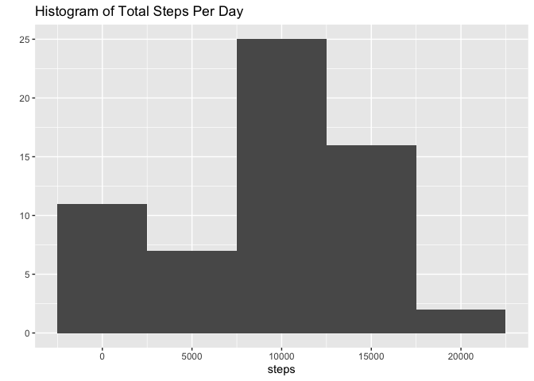

```r
total_steps_day <- activity %>% group_by(date) %>% summarise(steps = sum(steps, na.rm = TRUE))
qplot(steps, data = total_steps_day, binwidth = 5000, main = "Histogram of Total Steps Per Day")
```

```r
mean_steps <- mean(total_steps_day$steps, na.rm = TRUE)
median_steps <- median(total_steps_day$steps, na.rm = TRUE)
```

**The mean of the total steps taken per day is *9354.23* and the median of the total steps taken per day is *10395***.

## What is the average daily activity pattern?

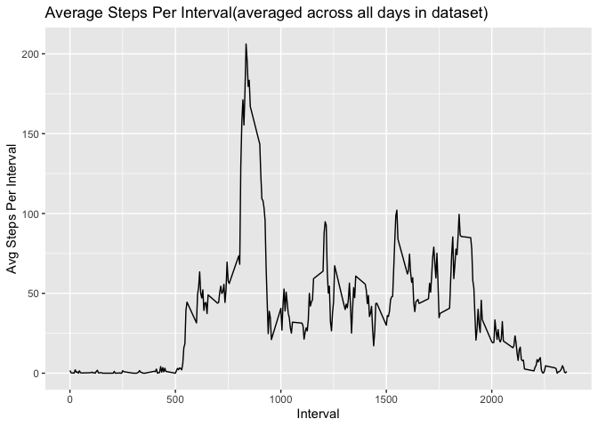

```r
avg_steps_interval <- activity %>% group_by(interval) %>% summarise(mean_steps = mean(steps, na.rm=TRUE))
qplot(interval, mean_steps, data = avg_steps_interval, geom = "line") + labs( x = "Interval", y = "Avg Steps Per Interval", title =  "Average Steps Per Interval(averaged across all days in dataset)")
```

```r
interval_max_mean_steps <- avg_steps_interval[avg_steps_interval$mean_steps == max(avg_steps_interval$mean_steps),1]
```

**The interval with maximum number of average steps, averaged across all days in the dataset, is *835***.

## Imputing missing values

**There are *2304* rows with missing values in the activity dataset.**

**We will use the mean steps taken in that interval, averaged across the days in the datset, to fill in missing values for that interval.**

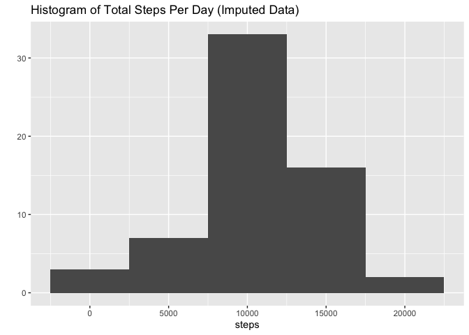

```r
activity_imputed <- activity %>% left_join(avg_steps_interval, by="interval") %>% mutate(steps = ifelse(is.na(steps),mean_steps,steps)) %>% select(steps, date, interval)

total_steps_day_imputed <- activity_imputed %>% group_by(date) %>% summarise(steps = sum(steps))
qplot(steps, data = total_steps_day_imputed, binwidth = 5000, main = "Histogram of Total Steps Per Day (Imputed Data)")
```

```r
mean_steps_imputed <- mean(total_steps_day_imputed$steps)
median_steps_imputed <- median(total_steps_day_imputed$steps)
```

**With missing steps imputed with the mean steps of that particular interval of the day, the mean of the total steps taken per day is *10766.19* and the median of the total steps taken per day is *10766.19***.

## Are there differences in activity patterns between weekdays and weekends?

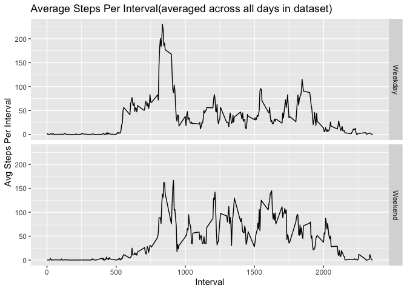

```r
activity_imputed <- activity_imputed %>% mutate(weekday = ifelse(weekdays(date) %in% c("Saturday","Sunday"), "Weekend", "Weekday"))

avg_steps_interval_imputed <- activity_imputed %>% group_by(interval,weekday) %>% summarise(mean_steps = mean(steps), .groups = 'drop')

ggplot(data = avg_steps_interval_imputed, aes(x=interval, y=mean_steps)) + geom_line() +facet_grid(rows = vars(weekday)) + labs( x = "Interval", y = "Avg Steps Per Interval", title =  "Average Steps Per Interval(averaged across all days in dataset)")
```